# **is**

- a EPSRC PhD researcher looking at **responsible public sector machine learning** at [University College London’s Department of Science, Technology, Engineering and Public Policy (UCL STEaPP)](https://www.ucl.ac.uk/steapp), supervised by Dr Jason Blackstock and Prof Anthony Finkelstein (Government Chief Scientific Advisor, National Security).
- an external researcher on the [Royal Society’s data governance science-policy project](https://royalsociety.org/topics-policy/projects/data-governance/).
- an advisor on machine learning for climate resilience at the [Red Cross Red Crescent Climate Centre](http://www.climatecentre.org).
- a social scientist, policy scholar and machine learning practitioner.
- [@mikarv on](http://twitter.com/mikarv) and on [Linked](https://www.linkedin.com/in/mveale) and the [UCL website](http://www.ucl.ac.uk/steapp/people/veale).
- this person

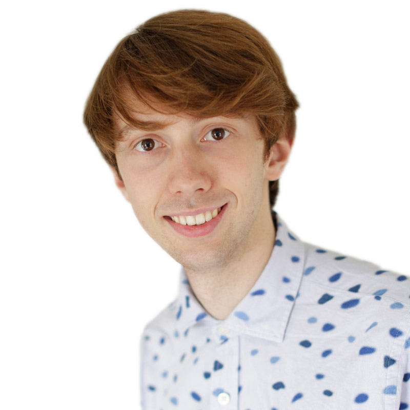

## and was…

- a trainee policy officer at the European Commission, [DG Health and Food Safety (SANTE)](http://ec.europa.eu/dgs/health_food-safety/), working on technology and innvoation policy around [ageing and connected devices](https://ec.europa.eu/eip/ageing/).
- a researcher on science-advice to policy at UCL.
- a visiting data scientist at sustainable sugarcane certifier [Bonsucro](http://bonsucro.com).
- a master’s student at Maastricht University (*cum laude*) and a bachelor’s student at LSE (*first-class honours*)

# **does**

## research

**Responsible public sector machine learning**

`status:ongoing` `type:PhD` `funder:EPSRC`

Machine learning, a set of technologies that identify and utilise patterns in data, is seeing more operational use in the public sector. Areas of current deployment include taxation, policing, child protection, food safety and justice. Yet responsible use of machine learning must sidestep issues of fairness, accountability, transparency, reliability, legality, liability and more. Technical tools are being developed to help here, but these won’t work if they’re airdropped in. I study the social aspects of the deployment of fairer and more responsible machine learning systems, with the aim of understanding how to do it better. I do this by

- interviewing public sector actors to understand how ethics do (or don’t) get into public sector machine learning today.
- engaging in action research within the public sector to develop and test social and technical tools for more responsible public sector machine learning tomorrow.

Supervisors: [Dr Jason Blackstock](https://www.ucl.ac.uk/steapp/people/blackstock) (UCL STEaPP), [Prof Anthony Finkelstein](http://www0.cs.ucl.ac.uk/staff/A.Finkelstein/profile.html) (Government Office for Science)

**Machine learning for humanitarian early warning systems**

`status:ongoing` `type:standalone` `funder:UCL STEaPP` `funder:UCL Public Policy`

Collaborators: [Dr Pablo Suarez](http://www.climatecentre.org/about-us/our-people) (Red Cross Red Crescent Climate Centre)

## teaching

**Analytic Methods for Policy**

`type:masters-MPA` `org:UCL STEaPP` `role:co-leader` `role:co-designer` `status:2016-` `length:20 sessions`

Co-lead and redesiged compulsory applied mixed-methodology policy research skills course for UCL STEaPP’s [Master’s of Public Administration (MPA)](https://www.ucl.ac.uk/steapp/study/masters) in Science, Engineering and Public Policy.

- data science for policy (R language)
- evidence synthesis and rapid evidence assessment
- experimental and quasi-experimental methods
- systems mapping and modelling

**Internet Law and Policy**

`type:masters-LLM` `org:U of Strathclyde` `role:guest lecturer` `status:2017` `length:1 session` `courseleader:Lilian Edwards`

Guest lectured around the policy challenges of machine learning.

**Ethics and Law**

`type:undergraduate` `org:UCL Laws` `role:guest lecturer` `status:2017` `length:1 session` `courseleader:Sylvie Delacroix`

Leader of guest hybrid lecture—seminar on ethics, machine learning and the law.

## consultancy

**Royal Society Science Policy Team**

`status:2016-`

Researcher (consultant—ext) for the Data Governance policy project; supporting the Machine Learning policy project.

**UCL ENGins**

`status:2015-`

Editor curating technical engineering news for practitioner and educational audiences on the [UCL ENGins](http://uclengins.org) platform for the Engineering, Environment and Energy and Law and Policy sectors.

# **produces**

## blogs

- book reviews at [LSE Review of Books](http://blogs.lse.ac.uk/lsereviewofbooks/category/book-reviewers/michael-veale/).
- [Computer scientists and social scientists must work together on algorithms](http://www.nesta.org.uk/blog/shadow-smart-machine-computer-scientists-and-social-scientists-must-work-together-algorithms) for [Nesta](http://www.nesta.org.uk) (2016)

## talks and presentations

`2017-03-31` [TRILCon 2017, U Winchester](http://www.winchester.ac.uk/academicdepartments/Law/Centre%20for%20Information%20Rights/Pages/-TRILCon17.aspx) // *How do public sector values get into public sector machine learning systems, if at all?* `upcoming!`

`2017-03-31` [The Politics of Algorithmic Modelling, ULB, Brussels](http://www.crids.eu/fichiers/politique-de-la-modelisation-algorithmique-programme) // *How do public sector values get into public sector machine learning systems, if at all?* `upcoming!`

`2017-03-21` [UCL STEaPP Public Seminar, London](https://www.ucl.ac.uk/steapp/news-and-events) // *What might responsible public sector machine learning look like?*

`2017-03-06` [AI for Social Good, Waseda University, Tokyo](https://www.digitalasiahub.org/2017/02/27/ai-in-asia-ai-for-social-good/) // *The present and future of responsible machine learning in the public sector.* [[slides](https://www.dropbox.com/s/8ty3krzo1b0pyow/mveale_waseda_presentation.pdf?dl=0)]

`2017-02-15` [Algorithm Workshop, U Strathclyde, Glasgow](https://www.strath.ac.uk/humanities/lawschool/newsevents/algorithmworkshopfebruary2017/) // *What algorithms are, why they might need governing, and how we might do it.* [[slides](https://www.dropbox.com/s/vit0j2qlmx55qtb/strathclyde_algorithms_mveale%20%28smaller%29.pdf?dl=0)]

`2016-12-07` [KIN Winter Workshop, WMG, U Warwick](http://www.ki-network.org/jm/membership) [[vid](http://podcasts.ki-network.org/2016-4/veale.mp4)]

`2016-12-16` The Human Use of Machine Learning, Venice // *How do public sector values get into public sector machine learning systems, if at all?*

`2016-11-28` Ethics of Machine Learning in Professional Practice, U Cambridge // *How do public sector values get into public sector machine learning systems, if at all?*

`2016-09-15` EIT Digital Pit Stop, Digital Catapult, London // *Paths and strategies for responsible machine learning in local government (keynote)*

`2016-06-28` Technology, Management and Policy Graduate Consortium, U Cambridge // *Machine learning for public sector decision-making: Evaluating risks and impacts*

`2016-05-26` Superhuman: Human and AI in Synergy, Microsoft Research, Cambridge // *Human and AI: Where to draw the lines?*

`2016-03-30` Knowing Algorithms, U Lancaster // *The governance challenges of advanced learning algorithms*.

# **can be contacted**

m.veale@ucl.ac.uk ([public key](https://keybase.io/mrv)) // +44 (0) 2031 089 736 // @mikarv